# Exam 2017

Exam nr. 38

16 januar 2017

Let the setup be as stated in the exam.

From the independence between $X$ and $Z$ we have
$$P(X=i,Z=j) =
\begin{cases}
\pi_x\pi_z , \quad &(i,j) = (1,1) \\
\pi_x(1-\pi_z) , \quad &(i,j) = (1,0) \\
(1-\pi_x)\pi_z , \quad &(i,j) = (0,1) \\
(1-\pi_x)(1-\pi_z) , \quad &(i,j) = (0,0)
\end{cases}$$
Let
$$A_0(t) = \int_0^t\alpha_0(s)ds$$
be the cumulative baseline hazard function which is unspecified and can be seen as an infinite dimensional, non-parametric, unknown of the cox model. From the cox form we therefore have the cumulative hazard:
$$\begin{align*}
A(t) &=
\int_0^t \alpha_0(s)\exp(X\beta + Z\gamma)ds \\
&= A_0(t)\exp(X\beta + Z\gamma)
\end{align*}$$

From which the survival function takes the form:
$$P(T > t) = \exp(-A(t))$$
one could also integrate out the statespace of $X$ and $Z$ to obtain:
$$\begin{align*}
P(T > t) &= \sum_{i,j}P(T > t, X = i, Z = j) \\
&= \sum_{i,j}P(T > t| X = i, Z = j) P(X = i, Z = j) \\
&= \sum_{i,j}\exp\left(-A_0(t)\exp(i\beta + j\gamma)\right) P(X = i, Z = j)
\end{align*}$$

The covariate distribution among surviviors, is then given by:

$$\begin{align*}
P(X = i, Z = j|T > t) &=
\frac{P(T > t | X = i, Z = j) P(X = i, Z = j)}{P(T > t)} \\
&= \frac{\exp\left( -A_0(t)\exp(i\beta + j\gamma) \right) P(X = i, Z = j)}
{\sum_{i,j}\exp\left(-A_0(t)\exp(i\beta + j\gamma)\right) P(X = i, Z = j)} \\
&= \frac{P(X = i, Z = j)}
{\sum_{i^\prime,j^\prime}\exp\left( A_0(t)\left[\exp(i\beta + j\gamma) - \exp(i^\prime\beta + j^\prime\gamma \right] \right) P(X = i^\prime, Z = j^\prime)}
\end{align*}$$

From this we see that the limiting distribution of the covariates given survival depends on $\beta$ and $\gamma$ in the following way:
$$\begin{aligned}
&\text{if} \quad \beta < 0, \gamma < 0: \\
&\lim_{t\to\infty} P(X=i,Z=j | T > t) =
\begin{cases} 1, \quad i = 1, j = 1 \\
0, \quad \text{otherwise}
\end{cases}
\\ \hline
&\text{if}\quad \beta > 0, \gamma > 0: \\
&\lim_{t\to\infty} P(X=i,Z=j | T > t) =
\begin{cases} 1, \quad i = 0, j = 0 \\
0, \quad \text{otherwise}
\end{cases}
\\ \hline
&\text{if}\quad \beta < 0, \gamma > 0: \\
&\lim_{t\to\infty} P(X=i,Z=j | T > t) =
\begin{cases}1, \quad i = 1, j = 0 \\
0, \quad \text{otherwise}
\end{cases}
\\ \hline
&\text{if} \quad \beta < 0, \gamma = 0: \\
&\lim_{t\to\infty} P(X=i,Z=j | T > t) =
\begin{cases}
\pi_z, &i = 1, j = 1 \\
1-\pi_z, &i = 1, j = 0 \\
0, &\text{otherwise}
\end{cases}
\\ \hline
&\text{if}\quad \beta = 0, \gamma = 0: \\
&\lim_{t\to\infty} P(X=i,Z=j | T > t) = P(X = i, Z = j)
\end{aligned}$$
Where the omitted cases are defined symetrically to the corresponding case above.

In general the covariates will not be independent for the surviors. This is due to the initial independence being distorted by a favoring of combinations of $X$ and $Z$ rendering a lower hazard, regardless of the initial joint distribution.

To have conditional independence we need to get:
$$P(X = i, Z = j|T > t) = P(X=i|T > t)P(Z=j|T > t)$$
for all $i,j \in \{0,1\}, t>0.$

To keep the independence also among the survivors one needs to offset the effect from $\beta$ and $\gamma$ corresponding to the initial distribution. We start by noting the trival case of setting $\beta = \gamma = 0$ in which case on gets, from the formula above:
$$\begin{align*}
P(X = i, Z = j|T > t)
&=
\frac{\exp\left( -A_0(t) \right) P(X = i, Z = j)}
{
\exp\left(-A_0(t) \right)
\left\{ (1-\pi_x)(1-\pi_z) + \pi_x (1-\pi_z) + (1-\pi_x)\pi_z + \pi_x\pi_z \right\}
} \\
&=
P(X=i, Z = j) \\
&=P(X=i)P(Z=j)
\end{align*}$$

Now let the hazard have the additive form, with interaction between X and Z modelled by the parameter $\rho$, now the cumulative hazard takes form:
$$A(t) = \int_0^t\alpha_0(s) + X\beta + Z\gamma + XZ\rho\,ds = A_0(t) + t(X\beta + Z\gamma + XZ\rho)$$

Hence we get the conditional survivor covariate distribution:
$$\begin{align*}
P(X = i, Z = j|T > t) &=
\frac{P(T > t | X = i, Z = j) P(X = i, Z = j)}{P(T > t)} \\
&= \frac{\exp\left( -A_0(t) -t(i\beta + j\gamma +ij\rho) \right) P(X = i, Z = j)}
{\sum_{i^\prime,j^\prime}\exp\left( -A_0(t) -t(i^\prime \beta + j^\prime \gamma +i^\prime j^\prime \rho) \right)
P(X = i^\prime, Z = j\prime)} \\
&=\frac{P(X = i, Z = j)}
{\sum_{i^\prime,j^\prime}\exp\left(t\left[\beta(i-i^\prime ) + \gamma(j-j^\prime ) +\rho(ij-i^\prime j^\prime) \right]\right) P(X = i^\prime, Z = j\prime)}
\end{align*}$$

for $i,j \in \{0,1\}, t > 0.$

The conditional marginal covariate distribution is now seen to be:
$$\begin{align*}
P(X = i, Z = j|T > t) &=
\frac{P(T > t | X = i, Z = j) P(X = i, Z = j)}{P(T > t)} \\
&= \frac{\exp\left( -A_0(t) -t(i\beta + j\gamma +ij\rho) \right) P(X = i, Z = j)}
{\sum_{i^\prime,j^\prime}\exp\left( -A_0(t) -t(i^\prime \beta + j^\prime \gamma +i^\prime j^\prime \rho) \right)
P(X = i^\prime, Z = j\prime)}
\end{align*}$$

We can decompose the process $N(t)$ into
$$dN(t) = \lambda(t)dt + dM(t) = X(t)dB(t) + diag(Y(t))h(Z(t)\gamma) + dM(t)$$
And since the martingale increments are iid. with mean zero, we will disregard these in the estimation of $B$, which is done through OLS;
$$\begin{align*}
\frac{\partial}{\partial dB(t)} \left( dN(t) - \lambda(t)dt\right)^{\otimes 2}
= -2(X(t))^T\left( dN(t) - \lambda(t)dt\right) = 0 \quad \Leftrightarrow \\
(X(t))^T dN(t) = (X(t))^T X(t) dB(t) + (X(t))^T diag(Y(t))h(Z(t) \gamma) dt \Leftrightarrow \\
dB(t) = \left( (X(t))^T X(t) \right)^{-1} (X(t))^T \left(dN(t) - diag(Y(t))h(Z(t) \gamma) dt \right)
\end{align*}$$
where we have assumed that $(X(t))^T X(t)$ is invertible. Hence we get
$$\hat{B}(t) = \int_0^t X^-(s) \left(dN(s) - diag(Y(s))h(Z(t) \gamma) \right) ds$$
where $X^-(t) = \left( (X(t))^T X(t) \right)^{-1} (X(t))^T.$

Since the event $\delta = 1$ occurs when $T$ is less than $U$, given $U=t$ we simply find that
$$P(\delta = 1 | U = t) = P(T < t) = 1 - P(T>t) = 1-e^{-\theta t}.$$
likewise one has that
$$P(\delta = 0 | U = t) = P(T > t) = e^{-\theta t}.$$
Now since the counting processes $N_j(t),\, j = 0,1$ can be seen in the light of the standard counting process setup, the difference being that no censoring is done. Since $N_0(t)$ only jumps, in $t = U$ when $U\leq T$ we have that given information at time $t$:
$$\mathcal{F}_t = \sigma \{ 1(U \leq s, \delta = 0), 1(U\leq s, \delta = 1) \}$$
then $dN_0(t)$ is er bernoulli variable conditioned on $\mathcal{F}_{t-}$ which can only jump if $t \leq U$, which is measurable since we assume that $U$ is always observed, and $U < T$ since otherwise $N_0(t)$ will not jump. From the infitesimal interpretation of the hazard $\gamma(x)dx$ as the probability of an event in $[x, x+dx)$ where therefore get:
$$\begin{align*}
\mathbb{E}(dN_0(t)|\mathcal{F}_{t-})
&= 1(t\leq U)\gamma(t)dt\,\mathbb{E}(1(T\geq t)) \\
&= 1(t\leq U)\gamma(t)dt\,P(T\geq t) \\
&= 1(t\leq U)\gamma(t)dt\{e^{-\theta t} \}.
\end{align*}$$

Likewise for $N_1(t)$ since a jump can only occur if $T < U$ and $t \leq U$ we get:

$$\begin{align*}
\mathbb{E}(dN_1(t)|\mathcal{F}_{t-})
&= 1(t\leq U)\gamma(t)dt\,\mathbb{E}(1(T < t)) \\
&= 1(t\leq U)\gamma(t)dt\,P(T < t) \\
&= 1(t\leq U)\gamma(t)dt\{1 - e^{-\theta t} \}
\end{align*}$$
.

Now, by definition we need to show that

$$\left\langle M_{i0}, M_{k1} \right\rangle = 0$$
For all $1 \leq i,k \leq n$ Note that since
$$\left[ M_{i,0}, M_{k,1} \right](t) = \sum_{s\leq t}\Delta M_{i,0}(s)\Delta M_{i,1}(s) = 0$$
Since the jumps of $M_{i,j}$ comes purely from the counting process $N_{i,j}(t)$, for $i \neq k$ the probability of simultanious jumps is zero. For $i=k$ we note that only one of $M_{i,0}(s),M_{i,1}(s)$ will make a jump in $U_i$, if $U_i \leq T_i$ then $M_{i,0}$ will jump while if $U_i > T_i$ then $M_{i,1}$ will make the jump. Since the zero process in particular is a square integrable process, we get that the predictable covariation process $\left\langle M_{i0}, M_{k1} \right\rangle$ is the compensator of $\left[ M_{i,0}, M_{k,1} \right](t)= 0$ which by the uniqueness of the Doob-Meyer is simply the zero-process.

The orthogonality of $M_{\cdot 0}$ and $M_{\cdot 1}$ now simply follows from the predictable covariation process being bilinear, hence:

$$\left\langle M_{\cdot 0}, M_{\cdot 1} \right\rangle =
\left\langle \sum_{i =1}^n M_{i0}, \sum_{k=1}^nM_{k1} \right\rangle =
\sum_{1\leq i,k \leq n} \left\langle M_{i0}, M_{k1} \right\rangle =
0$$

Since $N_i(t) = N_{i0}(t) + N_{i1}(t)$ always jumps in $t=U_i$ no matter the value of $T$ we can follow the argument of seeing $dN_i(t)$ as a bernoulli variable. Since the hazard in both cases is $\gamma(s)$ one with probability $e^{-\theta t}$ the other with $1-e^{-\theta t}$ we get

$$\mathbb{E}(dN_i(t)) = Y_i(t)\left[ \gamma(t)(1-e^{-\theta t})dt + \gamma(t)e^{-\theta t}dt \right] = Y_i(t)\gamma(t)dt$$
Where $Y_i(t) = 1(t\leq U_i)$. Hence the compensator of $N_i(t)$ is

$$\Lambda_i(t) = \int_0^tY_i(s)\gamma(s)ds$$
With $Y(t) = \sum_{i = 1}^n Y_i(t)$ we then have that the compensator for $N(t)$ is given by
$$\Lambda(t) = \int_0^tY(s)\gamma(s)ds$$

From this we can write the decomposition:

$$M(t) = N(t) - \Lambda(t)$$
which is a local square integrable martingale with respect to $\mathcal{F}_t$ Further
$$N(t) = \int_0^tY(s)\gamma(s)ds + M(t) \Longleftrightarrow dN(t) = Y(t)d\Gamma (t) +dM(t)$$
Since $dM(t)$ is a zero-mean process this motivates the estimating equation of $\Gamma (t) = \int_0^t\gamma(s)ds$:

$$\hat{\Gamma}(t) = \int_0^t \frac{1}{Y(s)}dN(s)$$

We now assume that we observe in $[0,t]$. Let $t_1,t_2,...,t_n$ be the corresponding realisations of $T_i$. Assume that the realized sample of $u_i$ has $k$ samples outside of $[0,t]$ hence we have the order $u_{(1)} < u_{(2)} < \dots < u_{(n-k-1)} < u_{(n-k)} < u_{(n-k+1)} = u_{(n-k+2)} = \dots u_{(n)} =t$. we have 3 cases: For samples of $u_i$ that does not fall in the interval we only know that $u_i > t$ which happens with probability/has likelihood
$$P(U_i>t) = \exp\left(-\int_0^t\gamma(s)ds \right)$$
from the assumtions of the assignment. This factor will enter $k$ times. For $n-k$ samples within the interval, we can have $u_i \leq t_i \Leftrightarrow \delta_i = 0$ Then the sample $(u_i, \delta_i)$ has likelihood given by hazard times survival evaluated in $u_i$ times the probability that $u_i \leq T_i$ which is $e^{-\theta u_i}$ hence we have likelihood of $(u_i, \delta_i = 0)$:
$$\gamma(u_i) \exp \left( -\int_0^{u_i}\gamma(s)ds \right)e^{-\theta u_i}$$

On the other hand we can have $t_i < u_i \Leftrightarrow \delta_i = 1$ Then the sample $(u_i, \delta_i = 1)$ has likelihood given by hazard times survival evaluated in $u_i$ times the probability that $ T_i < u_i$ which is $1-e^{-\theta u_i}$ hence we have likelihood of $(u_i, \delta_i = 1)$:
$$\gamma(u_i) \exp \left( -\int_0^{u_i}\gamma(s)ds \right)\left\{ 1-e^{-\theta u_i} \right\}$$

Now, a neat way of book keeping the survival terms, which depend on the realied $u_i$’s is through the at risk indicator, $Y(s) = \sum_{i=1}^n 1(s \leq U_i)$ using the ordering of $u_i$’s given above, with $k$ $u_i$’s larger than t, we have:

$$\sum_{i = 1}^n \int_0^{u_i}\gamma(s)ds = \underbrace{n}_{=Y(u_{(1)})}\int_0^{u_{(1)}}\gamma(s)ds + \underbrace{(n-1)}_{=Y(u_{(2)})}\int_{u_{(1)}}^{u_{(2)}}\gamma(s)ds + \dots +
\underbrace{k}_{=Y(t)}\int_{u_{(n-k)}}^t\gamma(s)ds = \int_0^tY(s)\gamma(s)ds$$

Hence all of the terms of the form $\exp\left( -\int_0^{u_i}\gamma(s)ds \right)$ can be moved outside and kept in the term $\exp\left( -\int_0^tY(s)\gamma(s)ds \right)$. Case 2 and 3 only contributes if $u_i < t$ hence these are exponentiated with the indicatorfunction $1(u_i < t)$. Hence we get the likelihood, written with random variables instead of realised data:
$$L_t(\gamma(s), \theta; (U_i, \delta_i), i=1,...,n) = L_t = \exp\left( -\int_0^tY(s)\gamma(s)ds\right)
\prod_{i=1}^n
\left\{
\gamma(U_i)(1-e^{-\theta U_i})^{\delta_i} e^{-\theta U_i(1-\delta_i)}
\right\}^{1(U_i<t)}$$

Now, denote the score process

$$U_t(\theta) = \frac{\partial}{\partial \theta}\log L_t$$

Starting by taking log of $L_t$ we get:
$$\begin{align}
\log L_t &=
-\int_0^t Y(s)\gamma(s)ds + \sum_{i=1}^n1(U_i < t) \log \left[ \gamma(U_i)(1-e^{U_i\theta})^{\delta_i}e^{-U_i\theta(1-\delta_i)} \right] \\
&= -\int_0^t Y(s)\gamma(s)ds +
\sum_{i=1}^n 1(U_i < t) \log \gamma(U_i) +
\sum_{i=1}^n 1(U_i < t) \delta_i\log(1-e^{U_i\theta}) +
\sum_{i=1}^n 1(U_i < t) (-U_i\theta(1-\delta_i))
\end{align}$$

Differentiating with respect to $\theta$ the 2 first terms do not depend on $\theta$, hence
$$\begin{align}
\frac{\partial}{\partial \theta} \log L_t
&=
\sum_{i=1}^n 1(U_i < t) \delta_i\frac{U_ie^{U_i\theta})}{(1-e^{U_i\theta})} +
\sum_{i=1}^n 1(U_i < t) (-U_i(1-\delta_i))
\end{align}$$

Now, for the first sum notice that only terms with $\delta_i = 1$ are included, with $u_i \leq t$. Since the counting process $N_{\cdot 1}(s)$ only jumps if $T_i < U_i$ in the point $s = u_i$ we have that the sum can be written as an intergral wrt $N_{\cdot 1}(s)$ from $0$ to $t$ with integrand equal to sumnand, with points $u_i$ replaces with variable $s$ i.e.
$$\sum_{i=1}^n 1(U_i < t) \delta_i\frac{U_ie^{U_i\theta})}{(1-e^{U_i\theta})}
=\int_0^t\frac{se^{-s\theta}}{1-e^{-s\theta}}dN_{\cdot 1}(s)$$
For the second sum the argument is the same, since only terms with $U_i \leq t$ is included, we need integrate from $0$ to $t$, and by integrating wrt $N_{\cdot 0}(s)$ only terms with $\delta_i = 0 \Leftrightarrow U_i \leq T_i$ are included. Since the sum is over $-U_i$ the integrand is simply $-s$. i.e.
$$\sum_{i=1}^n 1(U_i < t) (-U_i(1-\delta_i)) = \int_0^t - s dN_{\cdot 0}(s)$$
and we therefore get that the score can be written as the sum of integrals integrated wrt the two counting processes.
$$\frac{\partial}{\partial \theta} \log L_t = \int_0^t\frac{se^{-s\theta}}{1-e^{-s\theta}}dN_{\cdot 1}(s) - \int_0^t s dN_{\cdot 0}(s)$$

The to find the compensator we argue using the intensity function. An argument, albeit heurestic, that the intensity function is zero and the compensatror therefore the zero-process, is to view the jumps of the score given $\mathcal{F}_{u-}$. we see that
$$\mathbb{E}\left[ d\int_0^u\frac{se^{-s\theta}}{1-e^{-s\theta}}dN_{i 1}(s) | \mathcal{F}_{u-} \right] = Y_i(u)(1-e^{-\theta u})\gamma(u)du\cdot u \frac{e^{-\theta u}}{1-e^{-\theta u}} = Y_i(u)\gamma(u)du\cdot u e^{-\theta u}$$
The term $Y_i(u)$ comes from the fact that the subject must be at risk for a jump to be able to occur, in that case a jump has probability $\gamma(u)dt$. The jump is only countet if $T_i < u$ which has probability $(1-e^{-\theta u})$. Finally the jump will be of size equal to the integrand.\ Similairly,
$$\mathbb{E}\left[ d\int_0^u\frac{se^{-s\theta}}{1-e^{-s\theta}}dN_{i 0}(s) | \mathcal{F}_{u-} \right] = Y_i(u)e^{-\theta u}\gamma(u)du\cdot u$$
From this we see that the difference in zero, hence the increments of $\frac{\partial}{\partial \theta} \log L_t$ is a zero-mean process. Addin to this that the process is clearly adapted, due to $N_{\cdot 0}$ and $N_{\cdot 1}$ being adapted, and clearly integrable we get that it is in fact a martingale.\ Loosely speaking the difference in probability of jumps with $\delta_i = 1,2$ is being offset by the size of the jumps.

Setup

We start by simulating the data as given in the exam. T and U are standard exponential i.e.
$$\theta = 1, \quad \gamma(s) = 1$$
hence $\Gamma(t) = \int_0^t\gamma(s)ds = t$

```r
n <- 400
T <- rexp(n = n, rate = 1)
U <- rexp(n = n, rate = 1)
delta <- as.numeric(T < U)
tau <- 1

#Observed data:
U.obs <- U*as.numeric(U < tau) + tau*as.numeric(U >= tau)
#delta is set missing/999 is U is not observed
delta.obs <- delta*as.numeric(U.obs < tau) + 999*as.numeric(U >= tau)
#status as to wheter U was observed or not
status <- as.numeric(U.obs < tau)

#collect as data frame
df <- data.frame(U.obs, delta.obs, status)
```

Be calculate $\hat{\Gamma}(t) = \int_0^t \frac{1}{Y(s)} dN(s)$ by noting that this is simply a sum adding one over the number of subjects at risk `sum(U.obs >= s)` at each timepoints of jumps of $N(t) = N_{\cdot 0}(t) + N_{\cdot 1}(t)$. Hence we calculate the vector of timepoints, and the cumulative reciprocal at risk set.

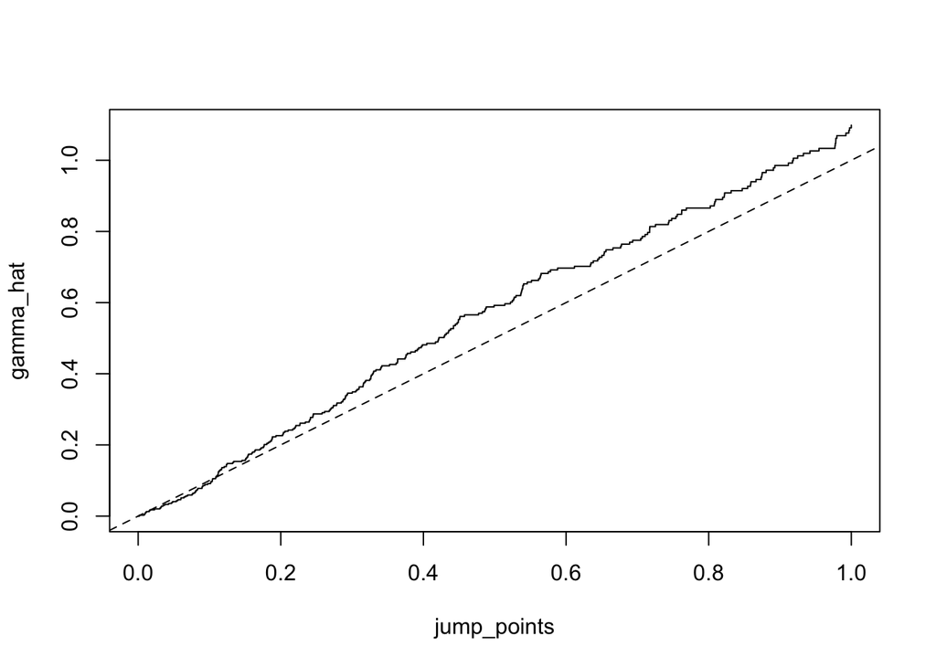

```r
jump_points <- unique(sort(U.obs))

risk_inv <- 1/sapply(X = jump_points, FUN = function(s) sum(U.obs >= s))

#add 0 point with 0 cum hazard
jump_points <- c(0, jump_points)
gamma_hat <- c(0,cumsum(risk_inv))

plot(jump_points, gamma_hat, type = "s")
abline(0,1, lty = 2)
```